# Mensik Experiments PS 4

Kristina Mensik

2026-10-04

Questions 1, 2, 3, 4, 5, 6, 7, 9, 10

# Question 1

### a

Covariates are “supplementary variables that predict outcomes” (G & G 95). They are not required for unbiased estimation. They’re used to improve precision by reducing variance in potential outcomes or differences between treatment and control observations in OLS, and to assign blocks in block randomized assignment. In theory, they are measured before subjects are randomized into treatment and control.

### b

“Disturbance term” refers to the part of a regression that is unobserved, which is unexplained variation in untreated and treated outcomes.

### c

Equation 4.2 demonstrates that rescaling the outcome by subtracting a pretest leads to unbiased estimates of the ATE. Subtracting the rescaled pretest $cX_j$ instead of the pre-test $X_i$ would….(show it produces unbaised estiamtes of the ATE).

Equation 4.2 says

$$E(\hat{ATE}) = E[Y_i - X_i|D_i = 1] - E[Y_i-X_i|D_i = 0]$$

The rescaled pretest $cX_i$ where $c$ is constant and positive can be substituted for $X_i$.

$$E(\hat{ATE}) = E[Y_i - cX_i|D_i = 1] - E[Y_i-cX_i|D_i = 0]$$

So when we expand as in 4.2:

$$E(\hat{ATE}) = E[Y_i|D_i = 1] - E[cX_i|D_i=1] - E[Y_i|D_i = 0] +
cE[X_i|Di=0]$$

…and rearrange:

$$E(\hat{ATE}) = E[Y_i|D_i = 1] - E[Y_i|D_i = 0] - c(E[X_i|D_i=1] +
E[X_i|Di=0])$$

…and because we assume that the expected values of $Y_i$ when $D_i = 0$ are the same as when $D_i = 1$, we arrive at the same place as in figure 4.2:

$$E(\hat{ATE}) = E(Y_i(1))-E[Y_i(0)]$$

### d

The slope parameter $b$ in equation 4.7 is the change in average potential outcomes $\mu_{Y1} - \mu_{Y0}$, also called the ATE.

$$E(ATE) = E[Y_i(1)] - E[Y_i(0)]$$

### e

Balanced designs are ideal because they allow for interval estimation: CI’s will be conservative rather than too wide or narrow from outcome variances with imbalance in the treatment and controls that produce. They’re particularly helpful when there is similar variance in the outcomes of treatment and control groups.

## Question 2

### a.

RI to test the null that pre-test scores are unaffected by treatment assignment.

```r
data_2 <- read.csv("/Users/kom11/Documents/GitHub/regression-study/Experiments/doi-10.60600-yu-vuh8kd/Gendelman_2004.csv")

set.seed(312608170)

names(data_2)
```

```
## [1] "subject"     "treatment"   "pretest"     "posttest"    "improvement"
```

```r
subject <- data_2$subject
treatment <- data_2$treatment
pretest <- data_2$pretest
posttest <- data_2$posttest
improvement <- data_2$improvement

model_2 <- lm_robust(treatment ~ pretest)

fstat_2 <- model_2$fstatistic[1] # get the f stat of treatment

fstat_2
```

```
##    value
## 1.268712
```

```r
# now random. inference with f-stat to get a p-value:

ra_2 <- declare_ra(nrow(data_2), m = 9) # random assignment procedure

perm_matrx_2 <- obtain_permutation_matrix(ra_2) #10k randomization permmatrix

estimates_2 <- c() #bucket to store results

for (i in 1:ncol(perm_matrx_2)) {

  data_2$ri <- perm_matrx_2[, i]

  random_inf_2 <- lm_robust(data_2$ri ~ data_2$pretest)

  estimates_2 <- c(estimates_2, random_inf_2$fstatistic[1])

}
```

The reported p-value is:

```r
print(mean(estimates_2 >= random_inf_2$fstatistic))
```

```
## [1] 0.2093
```

### b

```r
dim_2 <- difference_in_means(posttest ~ treatment, data = data_2)
dim_ate_2 <- dim_2$coefficients
```

Treatment’s effect on posttest scores is:

```r
print(dim_ate_2)
```

```
##  treatment
## -0.3333333
```

Now 95% CI constructed with randomization inference:

```r
set.seed(312608170)

null <- 0

dim_estimates_2 <- c()

data_2 <- data_2 %>%
  mutate(
    y0_null = case_when(
      treatment == 0 ~ posttest,
      treatment == 1 ~ posttest - null
    ),
    y1_null = case_when(
      treatment == 1 ~ posttest,
      treatment == 0 ~ posttest + null
    )
  )

unique(data_2$y1_null - data_2$y0_null == null)
```

```
## [1] TRUE
```

```r
for(i in 1:ncol(perm_matrx_2)){

   data_2$ri <- perm_matrx_2[, i] #hypothetical assignment


  data_2$y_temp <- ifelse(
    data_2$ri == 1,
    data_2$y1_null,
    data_2$y0_null
  )

  mean_treated <- mean(data_2$y_temp[data_2$ri == 1]) #DIM
  mean_control <- mean(data_2$y_temp[data_2$ri == 0])

  dim_estimates_2[i] <- mean_treated - mean_control #store

}

mean(dim_estimates_2) # should be centered around 0
```

```
## [1] -0.004688889
```

```r
# CI?

ci_2 <- quantile(dim_estimates_2, probs = c(0.025, 0.975))

ci_2
```

```
##      2.5%     97.5%
## -1.888889  1.888889
```

as a table:

```r
knitr::kable(ci_2, caption = "CIs for DIM", col.names = "Est.")
```

CIs for DIM

|  | Est. |
| --- | --- |
| 2.5% | -1.888889 |
| 97.5% | 1.888889 |

### c

D-i-D to estimate effect of treatment on post-test score:

```r
did_2 <- difference_in_means(improvement ~ treatment, data = data_2)

did_ate_2 <- did_2$coefficients

print(did_ate_2)
```

```
## treatment
##         1
```

95% CI, and compare to interval from b.

```r
#CI's from difference_in_means() function

did_ci_2 <- c(
  lower = dim_2$conf.low,
  upper = dim_2$conf.high
)

did_ci_2
```

```
##     lower     upper
## -2.523652  1.856985
```

```r
knitr::kable(did_ci_2, caption = "CIs for DIM", col.names = "Est.")
```

CIs for DIM

|  | Est. |
| --- | --- |
| lower | -2.523652 |
| upper | 1.856985 |

## Question 3

This reporting policy does not offer up unbiased estimates because it is premised on the outcomes – seems like rather explicit researcher-induced bias. Whether or not to report results based on covariates included should only be decided by theory and expectations (pre-registered, ideally, hypotheses).

## Question 4

20 schools assigned to treatment and 20 schools assigned to controls

```r
getwd()
```

```
## [1] "/Users/kom11/Documents/GitHub/regression-study/Experiments"
```

```r
data_4 <- read.csv("./doi-10.60600-yu-vuh8kd/GerberGreenBook_Chapter4_Table_4_1.csv")

view(data_4)
```

### a

$$Y_i = d_iY_i(1) + (1-d_i)Y_i(0)$$

```r
data_4$obs_y <- ifelse(data_4$D == 1, data_4$y1, data_4$y0)

#regress treatment on observed outcomes

model_4 <- lm_robust(obs_y ~ D, data = data_4)

summary(model_4)
```

```
##
## Call:
## lm_robust(formula = obs_y ~ D, data = data_4)
##
## Standard error type:  HC2
##
## Coefficients:
##             Estimate Std. Error t value  Pr(>|t|) CI Lower CI Upper DF
## (Intercept)    26.85      3.430   7.828 1.919e-09   19.906    33.79 38
## D              10.70      4.709   2.272 2.883e-02    1.166    20.23 38
##
## Multiple R-squared:  0.1196 ,    Adjusted R-squared:  0.09644
## F-statistic: 5.162 on 1 and 38 DF,  p-value: 0.02883
```

```r
print(coef(model_4)["D"])
```

```
##    D
## 10.7
```

```r
dim_4 <- difference_in_means(obs_y ~ D, data = data_4)
dim_ate_4 <- dim_4$coefficients

print(dim_ate_4)
```

```
##    D
## 10.7
```

Is estimated slope the same as estimated ATE based on DIM

```r
mean(data_4$obs_y [data_4$D == 0]) #control group mean should = intercept value
```

```
## [1] 26.85
```

Yes. Being assigned to treatment is associated with 10.7 higher scores compared to not being assigned to treatment.The mean value of those not assigned to treatment is 26.85 (as shown in the coefficient estimate for the Intercept and the mean value of observed ys when D is 0).

### b

The condition in equation 4.6 requires that the sum of the slope coefficients from regressing treated and untreated outcomes on $X_i$ is > 1.

```r
model_4b <- lm_robust(y0 ~ x, data = data_4)
summary(model_4b)
```

```
##
## Call:
## lm_robust(formula = y0 ~ x, data = data_4)
##
## Standard error type:  HC2
##
## Coefficients:
##             Estimate Std. Error t value  Pr(>|t|) CI Lower CI Upper DF
## (Intercept)   1.3413    1.94469  0.6897 4.945e-01   -2.595    5.278 38
## x             0.9418    0.06015 15.6582 3.677e-18    0.820    1.064 38
##
## Multiple R-squared:  0.8707 ,    Adjusted R-squared:  0.8673
## F-statistic: 245.2 on 1 and 38 DF,  p-value: < 2.2e-16
```

```r
print(coef(model_4b)["x"])
```

```
##         x
## 0.9417928
```

```r
coef_4_b <- (coef(model_4b)["x"])

model_4b_2 <- lm_robust(y1 ~ x, data = data_4) #treated outcomes on x

summary(model_4b_2)
```

```
##
## Call:
## lm_robust(formula = y1 ~ x, data = data_4)
##
## Standard error type:  HC2
##
## Coefficients:
##             Estimate Std. Error t value  Pr(>|t|) CI Lower CI Upper DF
## (Intercept)    5.335    1.69687   3.144 3.231e-03   1.8995    8.770 38
## x              0.942    0.04528  20.804 2.283e-22   0.8503    1.034 38
##
## Multiple R-squared:  0.875 , Adjusted R-squared:  0.8717
## F-statistic: 432.8 on 1 and 38 DF,  p-value: < 2.2e-16
```

Sum the coefficients:

```r
print(coef(model_4b_2)["x"])
```

```
##         x
## 0.9420107
```

plus

```r
coef_4_b
```

```
##         x
## 0.9417928
```

Sum of the slope coefficients:

```r
0.9417928 + 0.9420107
```

```
## [1] 1.883803
```

. . . is greater than 1, which means the dependent variable needs to be rescaled to reduce sampling variability (but its not required for unbiasedness).

### c

```r
model_4c <- lm_robust(obs_y ~ D + x, data = data_4) #y on d and x

summary(model_4c)
```

```
##
## Call:
## lm_robust(formula = obs_y ~ D + x, data = data_4)
##
## Standard error type:  HC2
##
## Coefficients:
##             Estimate Std. Error t value  Pr(>|t|) CI Lower CI Upper DF
## (Intercept)   1.2163     1.9523   0.623 5.371e-01  -2.7395    5.172 37
## D             5.3155     1.5398   3.452 1.408e-03   2.1955    8.436 37
## x             0.9204     0.0427  21.555 1.532e-22   0.8339    1.007 37
##
## Multiple R-squared:  0.9013 ,    Adjusted R-squared:  0.896
## F-statistic: 232.6 on 2 and 37 DF,  p-value: < 2.2e-16
```

```r
print(coef(model_4c)["D"])
```

```
##        D
## 5.315536
```

Upon including the covariate, D’s coefficient estimate of the treatment effect is now smaller – nearly halved. This likely is from correcting an imbalance. The SE is also smaller, suggesting we should have greater confidence in the results from this covariate adjusted model than for the no-covariate DIM.

### d

```r
#randomization inference

set.seed(6081709)

declare_4c <- declare_ra(nrow(data_4), m = sum(data_4$D)) #declared RA procedure
declare_4c
```

```
## Random assignment procedure: Complete random assignment
## Number of units: 40
## Number of treatment arms: 2
## The possible treatment categories are 0 and 1.
## The number of possible random assignments is 137846528820.
## The probabilities of assignment are constant across units:
## prob_0 prob_1
##    0.5    0.5
```

```r
#10k matrix

matrix_4 <- replicate(100000, conduct_ra(declare_4c))

estimates_4 <- rep(NA, 100000)

# dim for every permutation

for (i in 1:ncol(matrix_4)) {
  data_4$ri <- matrix_4[, i]

  estimates_4 [i] <- lm_robust(obs_y ~ ri, data = data_4)$coef["ri"]
}

print(round(mean(estimates_4), 2)) #centered enough around 0?
```

```
## [1] 0.01
```

The two sided p value is:

```r
print(mean(abs(estimates_4) >= abs(10.7)))
```

```
## [1] 0.03037
```

…and less than 0.05 so we are good to reject the sharp null that there isno effect for any school.

### e

```r
# Estimates from part (c):
coef_4c<-(coef(model_4c)["D"])

print(coef_4c)
```

```
##        D
## 5.315536
```

```r
#RI
set.seed(6081709)

coef_estimates_4c <- rep(NA, 100000)

for(i in 1:ncol(matrix_4)) {

  data_4$ri <- matrix_4[, i]

  coef_estimates_4c[i] <- lm(obs_y ~ ri + x, data = data_4)$coef["ri"]
}

length(coef_estimates_4c)
```

```
## [1] 100000
```

```r
mean(coef_estimates_4c) #centered around 0 (finally, forgot to add [i] to est loop)
```

```
## [1] 0.002510637
```

The p-value:

```r
print(mean(abs(coef_estimates_4c) >= abs(coef_4c)))
```

```
## [1] 0.00237
```

I get a two-sided p value is smaller than 0.05 so we can reject the sharp null hypothesis that there is no effect for any school.

### f

95% CI estimated with RI:

```r
#coef_4c

# fill in missing potential outcomes for each school

data_4$y0_ci <- ifelse(data_4$D == 0, data_4$obs_y, data_4$obs_y - dim_ate_4)

data_4$y1_ci <- ifelse(data_4$D == 0, data_4$obs_y + dim_ate_4, data_4$obs_y)

#started and stopped here, so checking treatment effect is 10.7 for both
unique(data_4$y1_ci - data_4$y0_ci)
```

```
## [1] 10.7 10.7
```

```r
# RI / simulate assignments

set.seed(6081709)

declare_4f <- declare_ra(nrow(data_4), m = sum(data_4$D))

ate_estimates_4 <- rep(NA, 100000) #init

sims_4     <- replicate(100000, conduct_ra(declare_4f))



#ate

for( i in 1:ncol(sims_4)) {

  data_4$ri <- sims_4[, i]

  data_4$y_temp <- data_4$y1_ci*data_4$ri + data_4$y0_ci*(1-data_4$ri)

  ate_estimates_4 [i] <- lm_robust(y_temp ~ ri, data = data_4)$coef["ri"]
}

# lower and upper bound

sort_ATEs <- sort(ate_estimates_4)

ci_f <- c(
  lower = sort_ATEs[2500], # could have also used qualtile dim_sims
  upper = sort_ATEs[97501]
)

ci_f
```

```
## lower upper
##  1.59 19.77
```

The CI (1.59, 19.77) remains above or does not cross 0, so we can reject the null hypothesis that there are no treatment effects.

### g

```r
# first get the tau (ATE from part C)
tau_4 <- (coef(model_4c)["D"]) # bc we're using covariate adjusted-estimate instead of assuming 10.7

tau_4
```

```
##        D
## 5.315536
```

```r
# then fill in potential outcomes (imputed Y1 imputed Y0)

data_4g <- data_4 %>%
  mutate(
    y0_imputed = case_when(
      D == 0 ~ obs_y,
      D == 1 ~ obs_y - tau_4
    ),
    y1_imputed = case_when(
      D == 1 ~ obs_y,
      D == 0 ~ obs_y + tau_4
    )
  )


# double checking that tau_4 (5.33) imposed constant treatment effect is treatment effect

unique(data_4g$y1_imputed - data_4g$y0_imputed)
```

```
## [1] 5.315536
```

```r
# simulate 100k

set.seed(6081709)

declare_4g <- declare_ra(nrow(data_4g), m = sum(data_4g$D))

ate_estimates_4g <- rep(NA, 100000) #init

sims_4g     <- replicate(100000, conduct_ra(declare_4g))


#ate

for( i in 1:ncol(sims_4g)) {

  data_4g$ri <- sims_4g[, i] # new treatment assignment
  #outcomes to correspond to above given assignment
  data_4g$y_temp <- data_4g$y1_imputed*data_4g$ri + data_4g$y0_imputed*(1-data_4g$ri)
  #regress new outcome on assignment and covariate (dif from f)
  ate_estimates_4g [i] <- coef(
    lm_robust(y_temp ~ ri + x, data = data_4g)
    )["ri"]
}

# lower and upper bound

sort_g_ATEs <- sort(ate_estimates_4g)

ci_f <- c(
  lower = sort_g_ATEs[2500], # could have also used qualtile dim_sims
  upper = sort_g_ATEs[97501]
)

ci_f
```

```
##    lower    upper
## 2.219570 8.425358
```

The CI here is considerably narrower than in 4f, which suggests greater precision. In other words, adding the pre-treatment scores to the estimate reduces the variability of estimated treatment effects, across repeated simulated assignments (also as suggested by 4b).

### Question 5

```r
data_5 <- read.csv("./doi-10.60600-yu-vuh8kd/GerberGreenBook_Chapter4_Table_4_1.csv")
```

#### a

```r
# restriction that a regression of $d_i$ on $X_i$ (the pre-test) generates and F stat whose reported p value is greater that 0.05. Ie were assigned $d_i$  significantly predicted by $X-i$, RI would be conducted again until $d_i$ met criterion.

# d is dataset, z is generated treatment assignment vector, x is name of covariate, m = number of schools assigned to treatment
restricted_assignment_5 <- function (d, x, m) {
  while (TRUE) {

    Z <- complete_ra(nrow(d), m) #generate a complete RA

    d$Z <- Z # add assignment to temporary df

    fit <- lm_robust(as.formula(paste("Z ~", x)),
                     data = d)

    f <- fit$fstatistic #has 3 numbers: value of F stat, numerator DoF, Denom DoF

    p.val <- 1 - pf(q = f[1], df1 = f[2], df2 = f[3])

    # keep only restriction-satisfier assignments
    if (p.val > 0.05){
      return(Z)
    }
  }
}

set.seed(6081709)

#  randomization (restricted) iterations
sim_matrix_5 <- replicate(10000,
                           restricted_assignment_5(d = data_5, x = "x",
                                         m = sum(data_5$D)))

# f stat where reported p val greater than 0.05?

fp <- c()

for (i in 1:ncol(sim_matrix_5)) {
  data_5$d_temp = sim_matrix_5[, i]
  f <- lm_robust(d_temp ~ x, data_5)$fstatistic
  fp[i] <- 1 - pf(q = f[1], df1 = f[2], df2 = f[3])
}

min(fp)
```

```
## [1] 0.05005605
```

```r
all(fp > 0.05)
```

```
## [1] TRUE
```

The min value of the created vector a p vals is just above the threshhold in a generous read (0.05005606 -> 0.05006 > 0.05000). I’m not sure if the hypothetical researcher would but I’ll take this as sufficient to proceed.

Weights?

```r
# about inverse probability weights

# already made matrix of treatment assignments to calculate the probabilities (matrix_5)

# can I use obtain conditional probabilities?

declare_5 <- declare_ra(permutation_matrix = sim_matrix_5)
declare_5 #declared restricted assignment  procedure
```

```
## Random assignment procedure: random assignment
## Number of units: 40
## Number of treatment arms: 2
## The possible treatment categories are 0 and 1.
## The number of possible random assignments is 10000.
## The probabilities of assignment are NOT constant across units. Your analysis strategy must account for differential probabilities of assignment, typically by employing inverse probability weights.
```

```r
# calculate probabilities and IPWs
data_5 <- data_5 %>%
  mutate(
    probs = obtain_condition_probabilities(declare_5, D),
    weights = 1 / probs
  )

# compare weights for treated units and control
data_5 %>%
  group_by(D) %>%
  summarize(
    mean_weight = mean(weights),
    sd_w = sd(weights),
    min_w = min(weights),
    max_w = max(weights),
    .groups = "drop"
  )
```

```
## # A tibble: 2 × 5
##       D mean_weight   sd_w min_w max_w
##   <int>       <dbl>  <dbl> <dbl> <dbl>
## 1     0        2.00 0.0242  1.95  2.05
## 2     1        2.00 0.0181  1.97  2.03
```

Weights vary by 0.024 SDs in the control group and by 0.018 in the treatment group.That seems like a small difference (ie, observed variation in estimated weights is small), and otherwise they are comperable. I know we can’t always assume that balance in terms of numbers in treatment and control has anything to do with covariate balance (or, equal C/T group size alone doesn’t mean equal probability of being treated).Here also reversing treatment or control assignment does not change the F stat (with 20 of 40 schools treated, true probability of being treated is 0.5, so everyone’s weight is 2).

#### b

```r
# constructing observed outcomes

#  actual DIM, weighted

data_5$obs_y <- ifelse(data_5$D == 1,
                       data_5$y1,
                       data_5$y0)

#estimate original treatment-control difference with 5a IPW
dim_5 <- difference_in_means(obs_y ~ D, weights = weights, data = data_5)

ate_dim_5 <- coef(dim_5)["D"] #treatment coefficient

print(ate_dim_5)
```

```
##        D
## 10.70463
```

```r
# sampling distribution under the null Y1 = Y0


#probability assigned to treatment x restricted randomizations:
p_treat_5 <- rowMeans(sim_matrix_5)

set.seed(6081709)

dim_estimates_5 <- rep(NA, ncol(sim_matrix_5))

## RI
for (i in 1:ncol(sim_matrix_5)) {

  data_5$ri <- sim_matrix_5[, i] # sim treatment assignment


  data_5$w_ri <- ifelse( #IPW re: simulated assignment
    data_5$ri == 1,
    1 / p_treat_5,
    1 / (1 - p_treat_5)
  )

# est treatment effect under sharp null
    dim_estimates_5 [i] <- coef(
      lm_robust(obs_y ~ ri, weights = w_ri, data = data_5)
      )["ri"]
}

print(mean(dim_estimates_5)) # is center on 0
```

```
## [1] -0.0002110398
```

```r
print(mean(abs(dim_estimates_5) >= abs(ate_dim_5))) # p-value
```

```
## [1] 0.0046
```

The p-value of 0.0046 lets us reject the sharp null: observed treatment effect is unusual enough under the sharp null (Y1=Y0) to reject the hypothesis of no treatment effect.

#### c

```r
# actual coefficients (weighted, covariate-adjusted)

model_5c <- lm_robust(obs_y ~ D + x,
                                      weights = weights, #ip each schools original assignment
                                      data = data_5)

summary(model_5c)
```

```
##
## Call:
## lm_robust(formula = obs_y ~ D + x, data = data_5, weights = weights)
##
## Weighted, Standard error type:  HC2
##
## Coefficients:
##             Estimate Std. Error t value  Pr(>|t|) CI Lower CI Upper DF
## (Intercept)   1.2299    1.95104  0.6304 5.323e-01   -2.723    5.183 37
## D             5.3082    1.54073  3.4453 1.435e-03    2.186    8.430 37
## x             0.9204    0.04262 21.5955 1.437e-22    0.834    1.007 37
##
## Multiple R-squared:  0.9012 ,    Adjusted R-squared:  0.8958
## F-statistic: 233.5 on 2 and 37 DF,  p-value: < 2.2e-16
```

```r
coef_5c <- coef(model_5c)["D"]

print(coef_5c)
```

```
##        D
## 5.308247
```

```r
# do RI
 # have sim_matrix_5: 10k criteria-meeting assignments ; obs_y: original observed post scores that under sharp null should be same for unit if treated as if untreated; p_treat_5: probability assigned to treatment x restricted randomizations

set.seed(6081709)

coef_estimates_5c <- rep(NA, 10000)

# estimating covariate-adjusted regression

for (i in 1:ncol(sim_matrix_5)) {

  data_5$ri <- sim_matrix_5[, i]

   data_5$w_ri <- ifelse( #IPW re: simulated assignment
    data_5$ri == 1,
    1 / p_treat_5,
    1 / (1 - p_treat_5)
  )

   # est treatment effect under sharp null
    coef_estimates_5c [i] <- coef(
      lm_robust(obs_y ~ ri + x, weights = w_ri, data = data_5)
      )["ri"]


}


# checking that the distribution is centred around 0

print(mean(coef_estimates_5c))
```

```
## [1] 0.0005049967
```

```r
# calculating the p-value

print(mean(abs(coef_estimates_5c) >= abs(coef_5c)))
```

```
## [1] 0.0029
```

```r
# compare sampling variability without then with cov adjustment
sd(dim_estimates_5)
```

```
## [1] 4.359096
```

```r
sd(coef_estimates_5c)
```

```
## [1] 1.801158
```

Here we get a two-sided p-val of 0.0029 which is less than 0.05 (we would very infrequently generate a covariate-adjusted treatment coefficient at least as extreme as that observed if treatment had no effect) we can reject the sharp null (no effect for any school).

Sampling variability shrinks notably with covariate adjustment – it “worked.”

#### d

Sampling distribution comparison: 5 (dim_estimates_5 and coef_estimates_5c) to 4 (estimates_4 and coef_estimates_4c) (latter assumed unrestricted randomization).

```r
# b and c were difference in means
# data_5_bc

#Restricted randomization unadjusted from 4 and 5
sd(estimates_4)
```

```
## [1] 4.958231
```

```r
sd(dim_estimates_5)
```

```
## [1] 4.359096
```

```r
# unrestricted randomization adjusted

sd(coef_estimates_4c)
```

```
## [1] 1.812093
```

```r
sd(coef_estimates_5c)
```

```
## [1] 1.801158
```

```r
df_5d <- rbind(
  data.frame(
    value = estimates_4,
    assignment = "unrestricted",
    estimator = "unadjusted"
  ),
  data.frame(
    value = dim_estimates_5,
    assignment = "restricted",
    estimator = "unadjusted"

  ),
  data.frame(
    value = coef_estimates_4c,
    assignment = "unrestricted",
    estimator = "covariate adjusted"
  ),
  data.frame(
    value = coef_estimates_5c,
    assignment = "restricted",
    estimator = "covariate adjusted"
  )
)

df_5d
```

[output not shown]

[output cut: 33320 more lines]

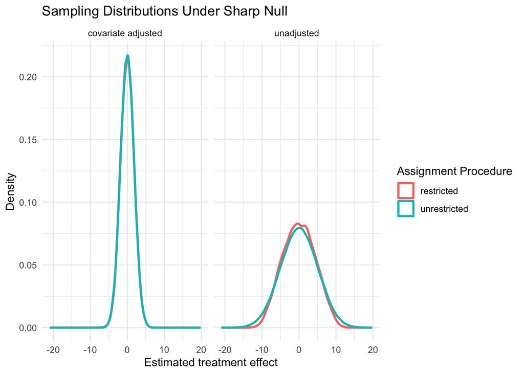

```r
ggplot(
  df_5d,
  aes(x = value, color = assignment)
) +
  geom_density(linewidth = 1) +
  facet_wrap(~estimator) +
  labs(
    title = "Sampling Distributions Under Sharp Null",
    x = "Estimated treatment effect",
    y = "Density",
    color = "Assignment Procedure"
  ) +
  theme_minimal()
```

The standard deviations reflect variability in estimated treatment effects across hypothetical random assignments. We see restricted randomization did reduce the SD, so “worked” in the sense that some variation the covariate would have ‘controlled’ was eliminated, by excluding hypothetical random assignments that would have had more of a relationship between covariates and the outcome (reduces chance covariate imbalance to sampling variability). The exclusion restriction of 0.05 might be a bit lax and only reduce extreme cases.

Comparing restricted randomization having adjustd for covariates: the difference is fairly negligible (see lefthand side of the plot above). This makes sense: regression already adjusts for pre-treatment scores, reducing whatever differences those scores would be associated with vis-a-vis estimates of treatment effects.

Perhaps the topline is restricted randomization and regression adjustment are able to address the same (or some of the same) conduits for sampling variability. At the same time, one (at least RR) doesn’t eliminate the value of the other (CA).

# Question 6

#### a

```r
data_6 <- read.csv("./doi-10.60600-yu-vuh8kd/OBrien_Patsiorkovski_ICPSR_1999.csv")

names(data_6)
```

```
## [1] "sexresp6" "ageresp6" "group6"   "memberc6" "index95"  "index96"  "index97"
## [8] "randsort"
```

```r
# adding observation/ids

data_6$villager <- seq_len(nrow(data_6))

data_6$group6 <- as.factor(data_6$group6) # social class variable as factor variable

# predict post-intervention by regressing variables

model_6a <- lm(index96 ~ sexresp6 + memberc6 + group6 + index95,
                data_6)

summary(model_6a)
```

```
##
## Call:
## lm(formula = index96 ~ sexresp6 + memberc6 + group6 + index95,
##     data = data_6)
##
## Residuals:
##     Min      1Q  Median      3Q     Max
## -4.6407 -1.0833  0.0080  0.8949  4.8970
##
## Coefficients:
##             Estimate Std. Error t value Pr(>|t|)
## (Intercept)  1.18988    0.72892   1.632    0.103
## sexresp6     0.24155    0.15729   1.536    0.125
## memberc6     0.19615    0.23319   0.841    0.401
## group62      0.38908    0.45406   0.857    0.392
## group63      0.62934    0.44538   1.413    0.158
## group64      0.79306    0.63737   1.244    0.214
## index95      0.54956    0.03319  16.560   <2e-16 ***
## ---
## Signif. codes:  0 '***' 0.001 '**' 0.01 '*' 0.05 '.' 0.1 ' ' 1
##
## Residual standard error: 1.437 on 455 degrees of freedom
## Multiple R-squared:  0.3937, Adjusted R-squared:  0.3857
## F-statistic: 49.24 on 6 and 455 DF,  p-value: < 2.2e-16
```

1996 evaluations of conditions seem most strongly predicted by 1995 evaluations – the other variables do not report a significant relationship. The $R^2$ is 0.3937: about 39% of the variation in the 1996 evaluations is explained by our model.

#### b

Block RA on sex, church, class, ’96 evaluations.

```r
set.seed(6081709)

# missingness in covs?
#colSums(is.na(data_6[c("sexresp6", "memberc6", "group6", "index96")]))
# no

# also want church and sex as factor
data_6 <- data_6 %>%
  mutate(sexresp6 = factor(sexresp6),
         memberc6 = factor(memberc6),
         group6 = factor(group6))



# pre-treatment cov matrix

matrix_6 <- model.matrix(~ sexresp6 + memberc6 + group6 + index96,
                          data = data_6)

# removing the intercept column, add villager ID instead

data_6_b <- data.frame(
  villager = data_6$villager,
  matrix_6[, -1, drop = FALSE]
)

stopifnot(nrow(data_6_b) == nrow(data_6))

head(data_6_b)
```

```
##   villager sexresp62 memberc62 group62 group63 group64 index96
## 1        1         1         1       0       0       0       6
## 2        2         0         1       0       1       0       6
## 3        3         1         0       0       1       0       6
## 4        4         1         1       0       1       0       3
## 5        5         0         1       0       1       0       6
## 6        6         0         1       1       0       0       3
```

```r
# blocking!

# if 42 block size, 11 blocks, 21 in treatment per 21 in control per; if 6 in each block, 77 blocks, 3 treated 3 untreated per
blocks_6 <- block(data_6_b, n.tr = 42, id.vars = "villager", block.vars = colnames(data_6_b)[-1])


# give blcok IDs to main DF
data_6_blocked <- data_6 %>%
  mutate(
    block = createBlockIDs(
      blocks_6,
      data_6_b,
      id.var = "villager"
    )
  )

# check number of units in each block
table(data_6_blocked$block)
```

```
##
##  1  2  3  4  5  6  7  8  9 10 11
## 42 42 42 42 42 42 42 42 42 42 42
```

```r
# conducting block random assignment

data_6_blocked <- data_6_blocked %>%
  mutate(
    D = block_ra(blocks = block, m = 21)
  )

#look at assignments within blocks
data_6_blocked %>%
  group_by(block, D) %>%
  summarize(n = n(), .groups = "drop")
```

```
## # A tibble: 22 × 3
##    block     D     n
##    <int> <int> <int>
##  1     1     0    21
##  2     1     1    21
##  3     2     0    21
##  4     2     1    21
##  5     3     0    21
##  6     3     1    21
##  7     4     0    21
##  8     4     1    21
##  9     5     0    21
## 10     5     1    21
## # ℹ 12 more rows
```

```r
#  check for covariate balance could mean with this one realized assignment, looking at whether treatment and control have comperable pre-treatment characteristics

data_6_blocked %>%
  group_by(D) %>%
  summarize(
    n = n(),
    mean_index96 = mean(index96, na.rm = TRUE),
    sd_index96 = sd(index96, na.rm = TRUE),
    .groups = "drop"
  )
```

```
## # A tibble: 2 × 4
##       D     n mean_index96 sd_index96
##   <int> <int>        <dbl>      <dbl>
## 1     0   231         5.76       1.83
## 2     1   231         5.70       1.84
```

```r
# f-tests to provide randomization-based balance check

# declare
declaration_6 <- declare_ra(
  N = nrow(data_6_blocked),
  blocks = data_6_blocked$block,
  block_m = rep(21, length(unique(data_6_blocked$block)))
)

block_m = rep(21, length(unique(data_6_blocked$block)))

# permutation matrix

perm_matrix_6 <- obtain_permutation_matrix(declaration_6)

# need actual realized treatment assignment F stat

f_observed_6 <- lm_robust(
  D ~ sexresp6 + memberc6 + group6 + index96,
  data = data_6_blocked
)$fstatistic[1]

f_observed_6
```

```
##     value
## 0.4491561
```

```r
# conducting repeated f-tests

repeated_f_tests <- numeric(ncol(perm_matrix_6))

# now ri
for (i in 1:ncol(perm_matrix_6)) {
  #assign t status
  data_6_blocked$d_temp = perm_matrix_6[, i]

  #calc f stat for simulated assignment
  repeated_f_tests[i] <- lm_robust(
    d_temp ~ sexresp6 + memberc6 + group6 + index96,
    data = data_6_blocked
  )$fstatistic[1]
}


# r i p value
mean(repeated_f_tests >= f_observed_6)
```

```
## [1] 0.4271
```

This distribution of p-values indicates that the groups are not systematically imbalanced across the control and treatment groups with regard to our covariates of interest.

#### c

```r
# setting seed

set.seed(6081709)

# running a for loop to generate sampling distributions - block ra

# creating empty vector to store results of for loop

ate_estimates_6c <- rep(NA, 10000)

# estimating ATE

for (i in 1:ncol(perm_matrix_6)) {
  data_6_blocked$ri <- perm_matrix_6[, i]

  ate_estimates_6c [i] <- lm(index97 ~ ri, data = data_6_blocked)$coef["ri"]

}

# checking that the distribution is centred around 0

print(round(mean(ate_estimates_6c), 2))
```

```
## [1] 0
```

```r
# running a for loop to generate sampling distributions - complete ra

# conducting complete random assignment

declaration_6c <- declare_ra(nrow(data_6), m = nrow(data_6)/2)
declaration_6c
```

```
## Random assignment procedure: Complete random assignment
## Number of units: 462
## Number of treatment arms: 2
## The possible treatment categories are 0 and 1.
## The number of possible random assignments is approximately infinite.
## The probabilities of assignment are constant across units:
## prob_0 prob_1
##    0.5    0.5
```

```r
# obtaining permutation matrix

perm_matrix_6c <- obtain_permutation_matrix(declaration_6c)

# creating empty vector to store results of for loop

ate_estimates_6c2 <- rep(NA, 10000)

# estimating ATE

for (i in 1:ncol(perm_matrix_6c)) {
  data_6$ri <- perm_matrix_6c[, i]

  ate_estimates_6c2 [i] <- lm(index97 ~ ri, data = data_6)$coef["ri"]

}

# checking that the distribution is centred around 0

print(round(mean(ate_estimates_6c2), 2))
```

```
## [1] 0
```

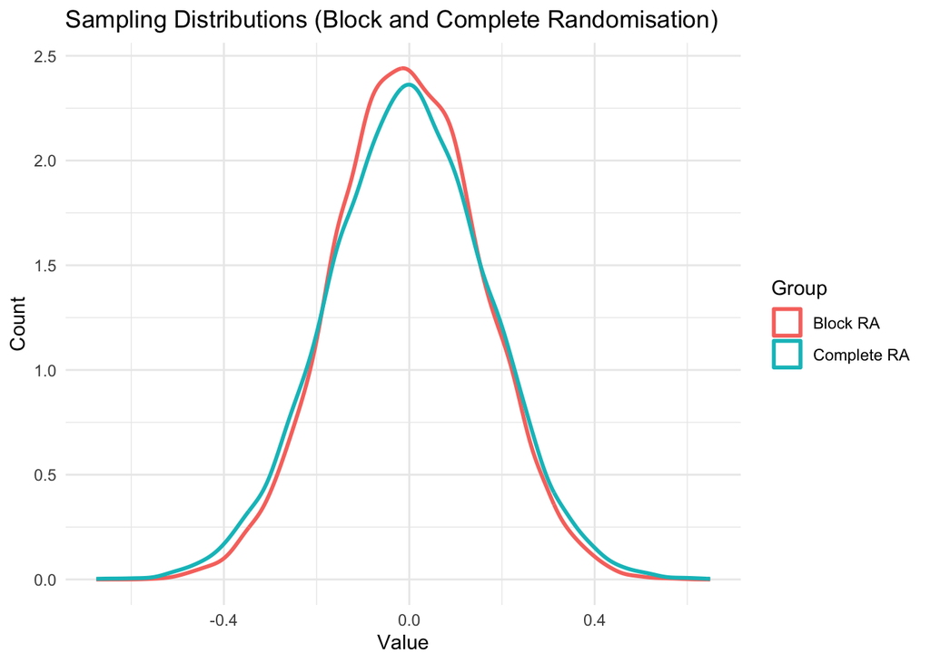

```r
# comparing sampling distributions under block and complete ra

data_6c <- data.frame(
  value = c(ate_estimates_6c, ate_estimates_6c2),
  group = factor(c(rep("Block RA", length(ate_estimates_6c)),
                   rep("Complete RA", length(ate_estimates_6c2))))
)

library(ggplot2)

ggplot(data_6c, aes(x = value, color = group)) +
  geom_density (alpha = 0.5, linewidth = 1) +
  scale_fill_manual(values = c("forestgreen", "lightblue")) +
  labs(title = "Sampling Distributions (Block and Complete Randomisation)",
       x = "Value", y = "Count", color = "Group") +
  theme_minimal()
```

The sampling distribution of the ATE under block random assignment is narrower and more clustered around the ‘true’ ATE of 0, than the corresponding sampling distribution under complete random assignment.

#### d

```r
# setting seed

set.seed(6081709)

# running for loop to generate distribution under covariate adjusted regression

# creating empty vector to store results of for loop

ate_estimates_6_d <- rep(NA, 10000)

# estimating ATE

for (i in 1:ncol(perm_matrix_6c)) {
  data_6$ri <- perm_matrix_6c[, i]

  ate_estimates_6_d [i] <- lm(index97 ~ ri +
                              sexresp6 +
                              memberc6 +
                              group6 +
                              index96, data = data_6)$coef["ri"]

}

# checking that the distribution is centred around 0

print(round(mean(ate_estimates_6_d)))
```

```
## [1] 0
```

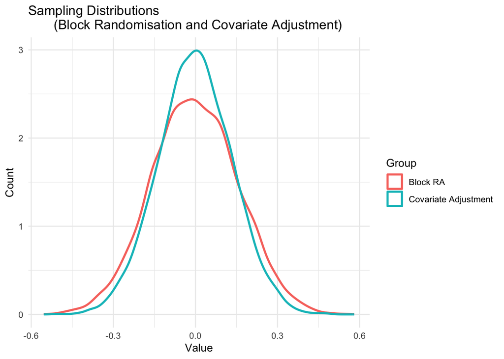

```r
# comparing sampling distributions under block ra and covariate adjustment

data_6c2 <- data.frame(
  value = c(ate_estimates_6c, ate_estimates_6_d),
  group = factor(c(rep("Block RA", length(ate_estimates_6c)),
                   rep("Covariate Adjustment", length(ate_estimates_6_d))))
)

library(ggplot2)

ggplot(data_6c2, aes(x = value, color = group)) +
  geom_density (alpha = 0.5, linewidth = 1) +
  scale_fill_manual(values = c("forestgreen", "lightblue")) +
  labs(title = "Sampling Distributions
       (Block Randomisation and Covariate Adjustment)",
       x = "Value", y = "Count", color = "Group") +
  theme_minimal()
```

The sampling distribution of the ATE under covariate adjustment is more clustered around the ‘true’ ATE of 0, than the corresponding sampling distribution under block random assignment.

## Question 7

### a

```r
data_7 <- data.frame(
          col1 = c("A", "B", "C", "D"),
          col2 = c(1, 0, 2, 5),
          col3 = c(2, 3, 2, 5))

colnames(data_7) <- c("Subject", "Y0", "Y1")


delcaration_7 <- declare_ra(
  N = nrow(data_7),
  m = 2
  )
delcaration_7
```

```
## Random assignment procedure: Complete random assignment
## Number of units: 4
## Number of treatment arms: 2
## The possible treatment categories are 0 and 1.
## The number of possible random assignments is 6.
## The probabilities of assignment are constant across units:
## prob_0 prob_1
##    0.5    0.5
```

```r
# creating the matrix of unique perms mechanically

D_7 <- obtain_permutation_matrix(delcaration_7)

dim(D_7)
```

```
## [1] 4 6
```

```r
# running a for loop to assess sampling variance of DIM estimator
# I use the standard R var function as we have no reason
# to believe this is the population

set.seed(6081709)

# creating empty vector to store results of for loop

dim_estimates_7 <- numeric(ncol(D_7))

# estimating dim

for (i in 1:ncol(D_7)) {

  data_7$ri <- D_7[, i]

  treated_mean <- mean(data_7$Y1[data_7$ri == 1])
  control_mean <- mean(data_7$Y0[data_7$ri == 0])

  dim_estimates_7[i] <- treated_mean - control_mean
}

var_7a <- mean(
  (dim_estimates_7 - mean(dim_estimates_7))^2
   )

var_7a
```

```
## [1] 2.833333
```

Sampling Variance is 2.833

#### b

```r
# run randomizations separately for each blocking scheme,  then cbind

# creating block assignments

block_options <- list(
  list(c("A","B"), c("C","D")),
  list(c("A","C"), c("B","D")),
  list(c("A","D"), c("B","C"))
)

get_block_data <- function(block_options, data) {

  subjects_ordered <- unlist(block_options)

  block_data <- data[match(subjects_ordered, data$Subject), ]

  block_data$Block <- rep(1:length(block_options), each = 2)

  return(block_data)
}

block_datasets <- lapply(block_options, get_block_data, data = data_7)

names(block_datasets) <- paste0("BlockOption", 1:3)

BlockOption1 <- block_datasets$BlockOption1
BlockOption2 <- block_datasets$BlockOption2
BlockOption3 <- block_datasets$BlockOption3

# randomising within blocking options - 1

delcaration_71 <- declare_ra(
  N = nrow(BlockOption1),
  blocks = BlockOption1$Block,
  block_m = rep(1, length(unique(BlockOption1$Block)))
)
delcaration_71
```

```
## Random assignment procedure: Block random assignment
## Number of units: 4
## Number of blocks: 2
## Number of treatment arms: 2
## The possible treatment categories are 0 and 1.
## The number of possible random assignments is 4.
## The probabilities of assignment are constant across units:
## prob_0 prob_1
##    0.5    0.5
```

```r
# randomising within blocking options - 2

delcaration_72 <- declare_ra(
  N = nrow(BlockOption2),
  blocks = BlockOption2$Block,
  block_m = rep(1, length(unique(BlockOption2$Block)))
)
delcaration_72
```

```
## Random assignment procedure: Block random assignment
## Number of units: 4
## Number of blocks: 2
## Number of treatment arms: 2
## The possible treatment categories are 0 and 1.
## The number of possible random assignments is 4.
## The probabilities of assignment are constant across units:
## prob_0 prob_1
##    0.5    0.5
```

```r
# randomising within blocking options - 3

delcaration_73 <- declare_ra(
  N = nrow(BlockOption3),
  blocks = BlockOption3$Block,
  block_m = rep(1, length(unique(BlockOption3$Block)))
)
delcaration_73
```

```
## Random assignment procedure: Block random assignment
## Number of units: 4
## Number of blocks: 2
## Number of treatment arms: 2
## The possible treatment categories are 0 and 1.
## The number of possible random assignments is 4.
## The probabilities of assignment are constant across units:
## prob_0 prob_1
##    0.5    0.5
```

```r
library(randomizr)

# extracting assignment vectors for each blocking optioon - 1 -3

assignment1 <- obtain_permutation_matrix(delcaration_71)
assignment2 <- obtain_permutation_matrix(delcaration_72)
assignment3 <- obtain_permutation_matrix(delcaration_73)

# reorder matrix rows so they match data_7 order


assignment1 <- assignment1[
  match(data_7$Subject, BlockOption1$Subject),
  , drop = FALSE
]

assignment2 <- assignment2[
  match(data_7$Subject, BlockOption2$Subject),
  , drop = FALSE
]

assignment3 <- assignment3[
  match(data_7$Subject, BlockOption3$Subject),
  , drop = FALSE
]

# combining for permmatrix of unique random assignments

perm_matrix_7b <- cbind(assignment1, assignment2, assignment3)


dim(perm_matrix_7b)
```

```
## [1]  4 12
```

```r
# running a for loop to assess sampling variance of DIM estimator
# I use the standard R var function as we have no reason
# to believe this is the population

# setting seed

set.seed(6081709)

# creating empty vector to store results of for loop

dim_estimates_7b <- numeric(ncol(perm_matrix_7b))

# estimating dim

for (i in 1:ncol(perm_matrix_7b)) {
  data_7$ri <- perm_matrix_7b[, i]

  treated_mean <- mean(data_7$Y1[data_7$ri == 1])
  control_mean <- mean(data_7$Y0[data_7$ri == 0])


  dim_estimates_7b[i] <- treated_mean - control_mean
}

  #sampling variance
  var_7b <- mean(
  (dim_estimates_7b - mean(dim_estimates_7b))^2
   )


var_7b
```

```
## [1] 2.833333
```

Variance is 2.833, same as in 7a.

### c

Randomly bocking or blocking on a non-prognostic covariate does not increase precision by design. It could by accident I suppose (or would that mean blocking on a covariate that is in fact progrostic, though not known to be?) but we see here that it can instead produce identical sampling variance as that given by complete random assignment.

# Question 9

```r
data_9 <- read.csv("./doi-10.60600-yu-vuh8kd/Gerber_Green_AAAPSS_2005.csv")
```

## a

The effect of getting phone banked on turnout was positive in Iowa districts that were not competitive. The effect was positive in the Michigan districts that were competitive, and negative in those that were non competitive. Neither was particularly pronounced.

## b

The composition of treated subjects within each block and differences in block sizes are obscured in the total ATE.

## c

The ATE estimated by overall Block:

```r
block1 <- 0.049487*0.00964
block2 <- 0.1520981*(-0.007829)
block3 <- 0.626616*(-0.01362)
block4<-0.171799*0.008271

ate_9 <- block1+block2+block3+block4

print(ate_9)
```

```
## [1] -0.007827282
```

## d

The OLS weights consider within-block balance and the size of blocks for control and treatment blocks. Balanced blocks have lower sampling variability than do imbalanced blocks, so balanced blocks are more heavily weighted. The OLS weights in 4.3 are more balanced than in part c.

## e

```r
# assignment counts per block
table(data_9$strata, data_9$treat2)
```

```
##
##          0      1
##   1  39618   6935
##   2 136074   7007
##   3 581919   7548
##   4 154385   7229
```

```r
# get assignment probabilities and IPWs

data_9_weighted <- data_9 %>%
  group_by(strata) %>%
  mutate(

    p_treat = mean(treat2 == 1),# proport assigned to treatment in each block

    q = ifelse( # p(receiving observed condition)
      treat2 == 1,
      p_treat,
      1 - p_treat
    ),

    weight = 1 / q #ipw

  ) %>%
  ungroup()


#regress after inverting weights

model_9e <- lm_robust(
  vote02 ~ treat2,
  weights = weight,
  data = data_9_weighted
)

summary(model_9e)
```

```
##
## Call:
## lm_robust(formula = vote02 ~ treat2, data = data_9_weighted,
##     weights = weight)
##
## Weighted, Standard error type:  HC2
##
## Coefficients:
##              Estimate Std. Error t value Pr(>|t|) CI Lower   CI Upper     DF
## (Intercept)  0.466198  0.0005227 891.860  0.00000  0.46517  0.4672221 940713
## treat2      -0.007828  0.0038723  -2.022  0.04323 -0.01542 -0.0002384 940713
##
## Multiple R-squared:  6.163e-05 , Adjusted R-squared:  6.056e-05
## F-statistic: 4.087 on 1 and 940713 DF,  p-value: 0.04323
```

```r
# would then regress weighted vote on treatment

ate_9e <- coef(model_9e)["treat2"]

ate_9e
```

```
##       treat2
## -0.007827966
```

```r
model_9e_blocks <- lm_robust(
  vote02 ~ treat2 + as.factor(strata),
  weights = weight,
  data = data_9_weighted
)

coef(model_9e_blocks)["treat2"]
```

```
##       treat2
## -0.007827966
```

Reproduced reported -0.00783 for weighted regression with blocking included, and weighted regression without blocking.

# Question 10

Cluster Random Design for KC voter mobilization.

```r
data_10 <- read.csv("./doi-10.60600-yu-vuh8kd/Arceneaux_AAAPSSsubset_2005.csv")

names(data_10)
```

```
##  [1] "unit"      "v_p2003"   "v_m2003"   "v_g2002"   "v_p2002"   "v_m2002"
##  [7] "v_s2001"   "v_g2000"   "v_p2000"   "v_m2000"   "v_s1999"   "v_m1999"
## [13] "v_g1998"   "v_m1998"   "v_s1998"   "v_m1997"   "v_s1997"   "v_g1996"
## [19] "v_p1996"   "v_m1996"   "v_s1996"   "treatment" "vote03"    "contact"
```

### a

```r
vote_vars_10 <- grep("^v_", names(data_10), value = TRUE)

vote_vars_10
```

```
##  [1] "v_p2003" "v_m2003" "v_g2002" "v_p2002" "v_m2002" "v_s2001" "v_g2000"
##  [8] "v_p2000" "v_m2000" "v_s1999" "v_m1999" "v_g1998" "v_m1998" "v_s1998"
## [15] "v_m1997" "v_s1997" "v_g1996" "v_p1996" "v_m1996" "v_s1996"
```

```r
avoiding_long_type <- reformulate(
  vote_vars_10,
  response = "treatment"
)

model_10a <- lm_robust(avoiding_long_type, data = data_10 )

f_stat_10 <- model_10a$fstatistic[1]
f_stat_10
```

```
##    value
## 1.654182
```

```r
# RI to test null that none of those vars preidcts treatment
# means cluster assignment

clusters_10 <- data_10 %>% #28 row summary for counting treated precincts
  group_by(unit) %>%
  summarize(
    treated = mean(treatment)
  )

declaration_10 = declare_ra(
  N = nrow(data_10),
  clusters = data_10$unit, #IDs precinct for each voter
  m = sum(clusters_10$treated))

declaration_10
```

```
## Random assignment procedure: Cluster random assignment
## Number of units: 9712
## Number of clusters: 28
## Number of treatment arms: 2
## The possible treatment categories are 0 and 1.
## The number of possible random assignments is 40116600.
## The probabilities of assignment are constant across units:
## prob_0 prob_1
##    0.5    0.5
```

```r
set.seed(6081709)

# RI

estimates_10 <- numeric(10000)

# f stats


for(i in 1:10000) {

  data_10$ri <- conduct_ra(declaration_10) #precint level assignment


  avoiding_long_type_2 <- reformulate(vote_vars_10,
                                    response = "ri")

  m10_temp <- lm_robust(avoiding_long_type_2, data = data_10) #get F stat for given assignment


estimates_10 [i] <- summary(m10_temp)$fstatistic[1]

}

pval10 <- mean((estimates_10) >= abs(f_stat_10)) #RI p val

f_stat_10
```

```
##    value
## 1.654182
```

```r
pval10
```

```
## [1] 0.9376
```

We cannot reject the null: observed association between turnout and treatment assignment is not distinguishable from (or not unusually large compared to) that which randomization by precinct could have produced by chance (ie not evidence of problematic covariate imbalance). 93.7% of simulated cluster assignments produced F-stats at least as large as 1.654.

### b

Have: declaration_10, clusters_10, vote_vars_10 is list of past votes

```r
prep_10b <- reformulate(
  c("treatment", vote_vars_10), #list of past votes
  response = "vote03"
)

model_10b <- lm_robust(
  prep_10b,
  data = data_10,
  clusters = unit #calc SEs acct for w/in precint dependence
)

summary(model_10b)
```

```
##
## Call:
## lm_robust(formula = prep_10b, data = data_10, clusters = unit)
##
## Standard error type:  CR2
##
## Coefficients:
##               Estimate Std. Error  t value  Pr(>|t|)  CI Lower  CI Upper    DF
## (Intercept) -0.0117076   0.019352 -0.60498 5.512e-01 -0.051755  0.028340 22.85
## treatment    0.0559620   0.017197  3.25413 3.660e-03  0.020283  0.091641 21.85
## v_p2003      0.2189582   0.020440 10.71203 2.762e-10  0.176612  0.261304 22.41
## v_m2003      0.2313273   0.012106 19.10841 2.403e-15  0.206245  0.256410 22.37
## v_g2002      0.1107360   0.008402 13.18032 4.310e-12  0.093339  0.128133 22.60
## v_p2002      0.0830995   0.017146  4.84671 7.198e-05  0.047589  0.118609 22.52
## v_m2002      0.0741270   0.018443  4.01927 5.841e-04  0.035858  0.112396 21.80
## v_s2001      0.0477243   0.013822  3.45277 2.199e-03  0.019106  0.076342 22.64
## v_g2000      0.0122360   0.013088  0.93488 3.594e-01 -0.014809  0.039281 23.47
## v_p2000      0.0455913   0.018577  2.45415 2.246e-02  0.007074  0.084108 22.10
## v_m2000      0.0185109   0.015558  1.18976 2.472e-01 -0.013812  0.050833 21.36
## v_s1999      0.0450664   0.010488  4.29705 3.070e-04  0.023283  0.066850 21.43
## v_m1999      0.0164240   0.014529  1.13041 2.706e-01 -0.013727  0.046575 21.76
## v_g1998      0.0133923   0.010028  1.33553 1.958e-01 -0.007441  0.034226 21.34
## v_m1998      0.0162324   0.016438  0.98749 3.347e-01 -0.017959  0.050424 20.93
## v_s1998      0.0234097   0.012331  1.89843 7.139e-02 -0.002225  0.049044 21.12
## v_m1997      0.0301064   0.016391  1.83675 8.046e-02 -0.003984  0.064197 20.97
## v_s1997     -0.0279659   0.012934 -2.16226 4.176e-02 -0.054791 -0.001141 21.97
## v_g1996      0.0255726   0.010879  2.35072 2.815e-02  0.003007  0.048138 21.92
## v_p1996     -0.0271313   0.017608 -1.54085 1.378e-01 -0.063681  0.009419 21.66
## v_m1996     -0.0001964   0.016846 -0.01166 9.908e-01 -0.035186  0.034793 21.43
## v_s1996     -0.0147401   0.023745 -0.62077 5.416e-01 -0.064190  0.034709 20.53
##
## Multiple R-squared:  0.3238 ,    Adjusted R-squared:  0.3223
## F-statistic:  1428 on 21 and 27 DF,  p-value: < 2.2e-16
```

```r
ate_10b <- model_10b$coefficients["treatment"]

ate_10b
```

```
##  treatment
## 0.05596196
```

Assignment to a treated precinct is associated with an increase of 5.6 percentage poings in one’s probability of voting in 2003, net of voting across the other 20 elections. The adjusted R2 suggests that 32.23% of observed variation in 2003 turnout (individual) is explained by the model containing turnout in past elections and treatment assignment.

```r
# RI to test sharp null treated outcome = untreated outcome



avoiding_long_type_2 <- reformulate(
    c("ri", vote_vars_10), #replace treatment with RI
    response = "vote03"
    )

# RI
set.seed(6081709)

n_sims_10b <- 10000

estimates_10b <- numeric(n_sims_10b)


# sim cluster assignments, est coefs

for(i in 1:10000) {

  data_10$ri <- conduct_ra(declaration_10) #precint level assignment


  m10_temp <- lm_robust(avoiding_long_type_2, data = data_10)

  estimates_10b[i] <- coef(m10_temp)["ri"] #get coef on simulated treatment assignment

}

# p val

pval10b <- mean(
  abs(estimates_10b) >= abs(ate_10b)
)

pval10b
```

```
## [1] 0.0045
```

Sharp null: Y0 = Y1. The p value for this sharp null is 0.0045 – this is less than the standard 0.05 cutoff and 0.01. Thus we can reject the null hypothesis (at both the 5% and 1% significance levels) that experimental assignment had no effect on decisions to vote in 2003 (only 0.45% of simulated random assignments under the sharp null generated treatment effects as extreme as that reported in the observed ATE.

### c

DIT

```r
precinct_10c <- data_10 %>%
  group_by(unit, treatment) %>%
  summarize(
    n_voters = n(),
    votes = sum(vote03),
    .groups = "drop"
  )

precinct_10c
```

```
## # A tibble: 28 × 4
##     unit treatment n_voters votes
##    <int>     <int>    <int> <int>
##  1     1         0      655   251
##  2     2         0      386    72
##  3     3         0      245    81
##  4     4         0      364   123
##  5     5         0      272    92
##  6     6         0      124    37
##  7     7         0      288    80
##  8     8         0      386   117
##  9     9         0      417   135
## 10    10         0      336    94
## # ℹ 18 more rows
```

```r
total_voted <- precinct_10c %>%
  group_by(treatment) %>%
  summarize(
    k = n(),
    total_votes = sum(votes),
    avg_votes = mean(votes),
    n_voters = sum(n_voters),
    .groups = "drop"
  )

total_voted
```

```
## # A tibble: 2 × 5
##   treatment     k total_votes avg_votes n_voters
##       <int> <int>       <int>     <dbl>    <int>
## 1         0    14        1392      99.4     4779
## 2         1    14        1654     118.      4933
```

```r
#DIT

K <- nrow(precinct_10c) # n precincts

N <- nrow(data_10) # n voters

avg_treated <- total_voted$avg_votes[total_voted$treatment == 1] #avg voters per treated precinct

avg_control <- total_voted$avg_votes[total_voted$treatment == 0] # avg voters per control precinct

# DIT for real then is:

dit <- (K/N) * (avg_treated - avg_control)


dit
```

```
## [1] 0.05395387
```

The DIT is 0.0539.

### d

RI to test sharp null with DIT

```r
# RI to test sharp null treated outcome = untreated outcome



avoiding_long_type_3 <- reformulate(
    c("ri", vote_vars_10), #replace treatment with RI
    response = "vote03"
    )

# RI
set.seed(6081709)

n_sims_10c <- 10000

estimates_10c <- numeric(n_sims_10c)


# sim cluster assignments, est coefs

for(i in 1:10000) {

  data_10$ri <- conduct_ra(declaration_10) #precint level assignment


  m10_temp <- lm_robust(avoiding_long_type_2, data = data_10)

  estimates_10c[i] <- coef(m10_temp)["ri"] #get coef on simulated treatment assignment

}

# p val

pval10c <- mean(
  abs(estimates_10c) >= abs(dit)
)

pval10c
```

```
## [1] 0.0063
```

### e

```r
# new "differenced" outcome var: dif between subjects turnout 1, 0 and average rate of turnout in all past elections

"vote03" %in% vote_vars_10
```

```
## [1] FALSE
```

```r
length(vote_vars_10)
```

```
## [1] 20
```

```r
data_10_differenced <- data_10 %>%
  mutate(
    past_avg = rowMeans(
      pick(all_of(vote_vars_10)),
      na.rm = TRUE
    ),

    vote03diff = vote03 - past_avg

  )


precinct_10e <- data_10_differenced %>%
  group_by(unit, treatment) %>%
  summarize(
    n_voters = n(),
    votes = sum(vote03diff),
    .groups = "drop"
  )


total_voted <- precinct_10e %>%
  group_by(treatment) %>%
  summarize(
    k = n(),
    total_votes = sum(votes),
    avg_votes = mean(votes),
    n_voters = sum(n_voters),
    .groups = "drop"
  )

total_voted
```

```
## # A tibble: 2 × 5
##   treatment     k total_votes avg_votes n_voters
##       <int> <int>       <dbl>     <dbl>    <int>
## 1         0    14       -19.2     -1.37     4779
## 2         1    14       217.      15.5      4933
```

```r
#DIT

K <- nrow(precinct_10e) # n precincts

N <- nrow(data_10_differenced) # n voters

avg_treated <- total_voted$avg_votes[total_voted$treatment == 1] #avg voters per treated precinct

avg_control <- total_voted$avg_votes[total_voted$treatment == 0] # avg voters per control precinct

# DIT for real then is:

dit_e <- (K/N) * (avg_treated - avg_control)


dit_e
```

```
## [1] 0.04874382
```

RI

```r
set.seed(6081709)

declaration_10e <- declare_ra( #declare, x precincts
  N = nrow(precinct_10e),
  m = sum(clusters_10$treated)
)

estimates_10e <- numeric(10000) #dit ests

for (i in 1:10000) {

  precinct_10e$ri <- conduct_ra(declaration_10e) #sim precinct assignments


  estimates_10e[i] <- (K / N) * (
    mean(precinct_10e$votes[precinct_10e$ri == 1]) -
    mean(precinct_10e$votes[precinct_10e$ri == 0]) #get dit est
  )
}

# p val, 2 sided
pval_10e <- mean(
  abs(estimates_10e) >= abs(dit_e)
)

dit_e
```

```
## [1] 0.04874382
```

```r
pval_10e
```

```
## [1] 0.0232
```

We can reject the sharp null at the 95% confidence level.